# EDA For Question2

U1813544

Then we extract all the variables from our variables list to our data frame.

### Overview

#### Let’s have a general overview on four chosen coutries.

##### Daily confirmed cases in the whole period in different countries.

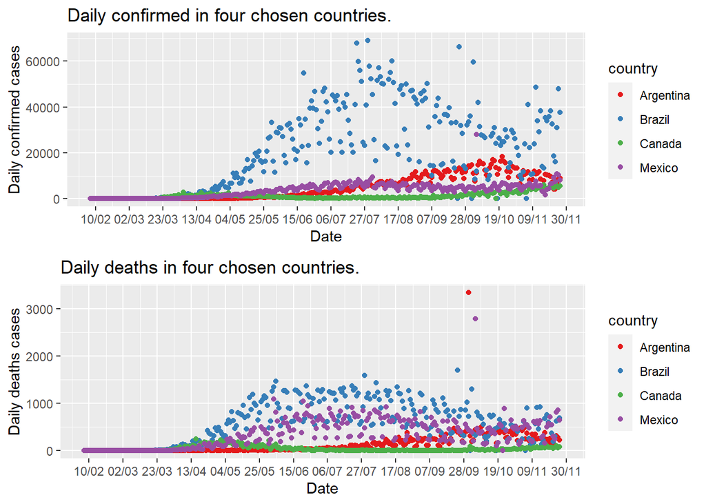

#### Brazil

##### 1.Daily confirmed cases in Brazil climbed up to 70,000 at the end of July and decreased until the beginning of November.Recently the number of daily confirmed cases has tendency to increase.

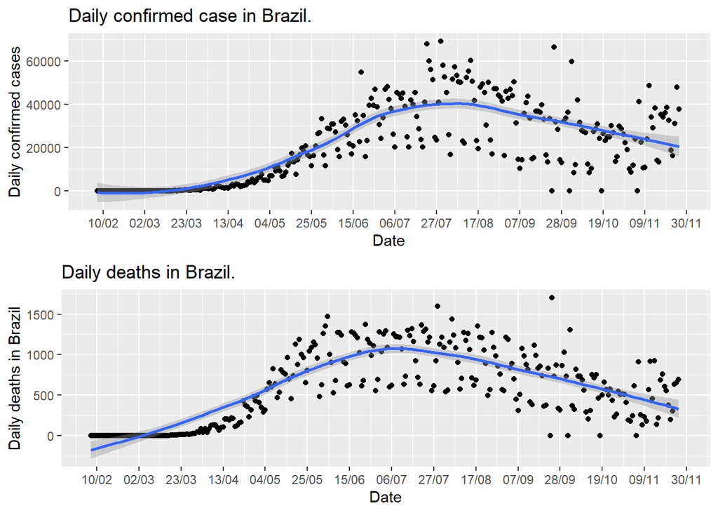

##### 2.Relationship between Number of daily confirmed cases and the frequency that people visit retail and recreation places in Brazil.

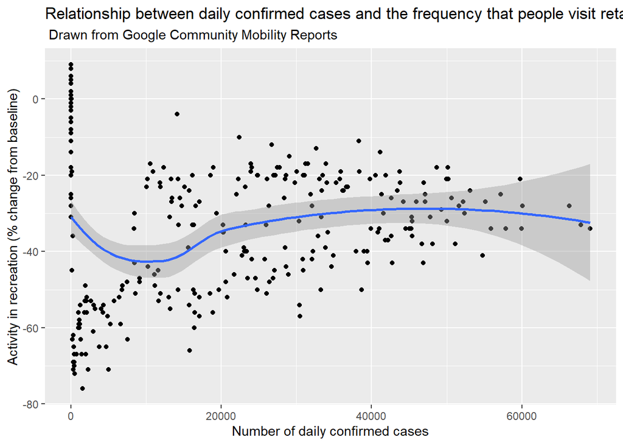

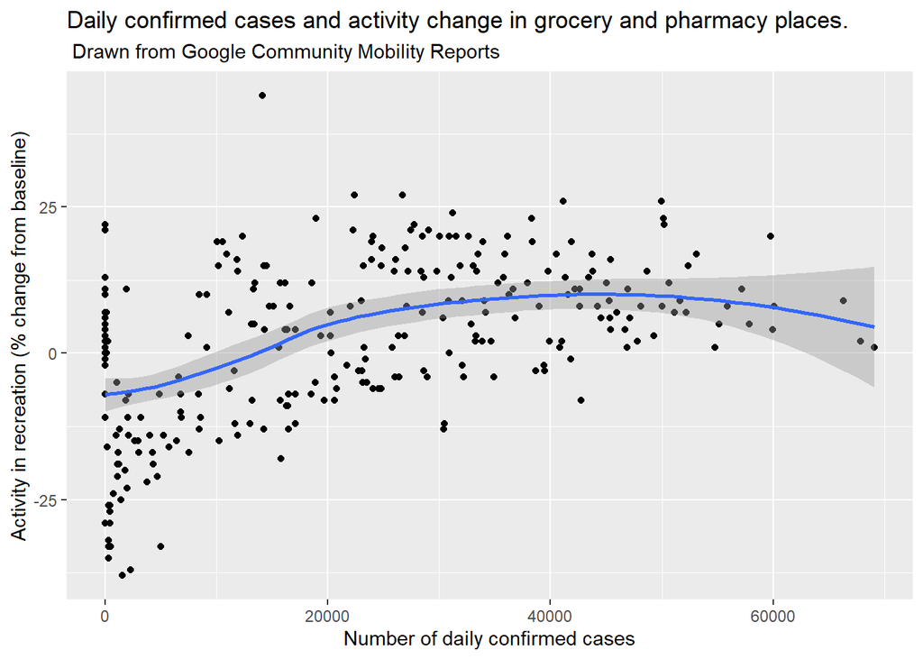

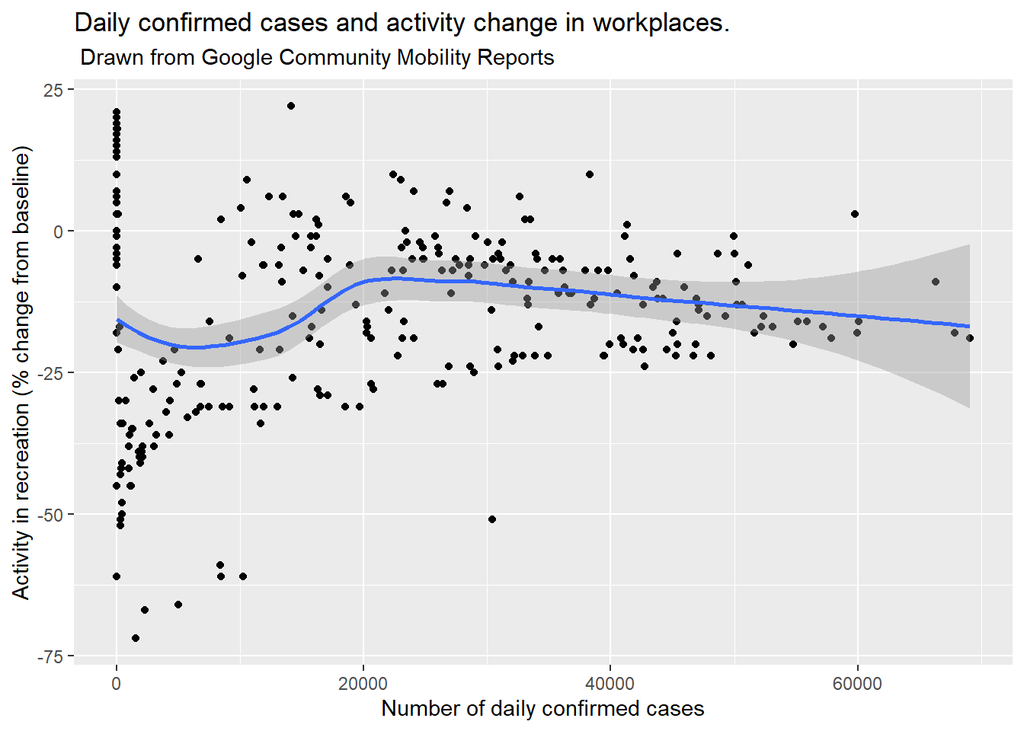

#### Canada

#####1.There are two phases in Canada so we divide into phase one and phase two. Phase one started at beginning of Feburary and reached 2,000 cases to one-month period with less than 1,000 daily confirmed cases. Second phase has started around August and it is noticeable that second wave reaches much higher daily confirmed cases.

[figure not shown]

#####2. For the first wave and second wave, the graph below shows relationship between number of daily confirmed cases and the frequency that people visit retail and recreation places in Canada respectively.

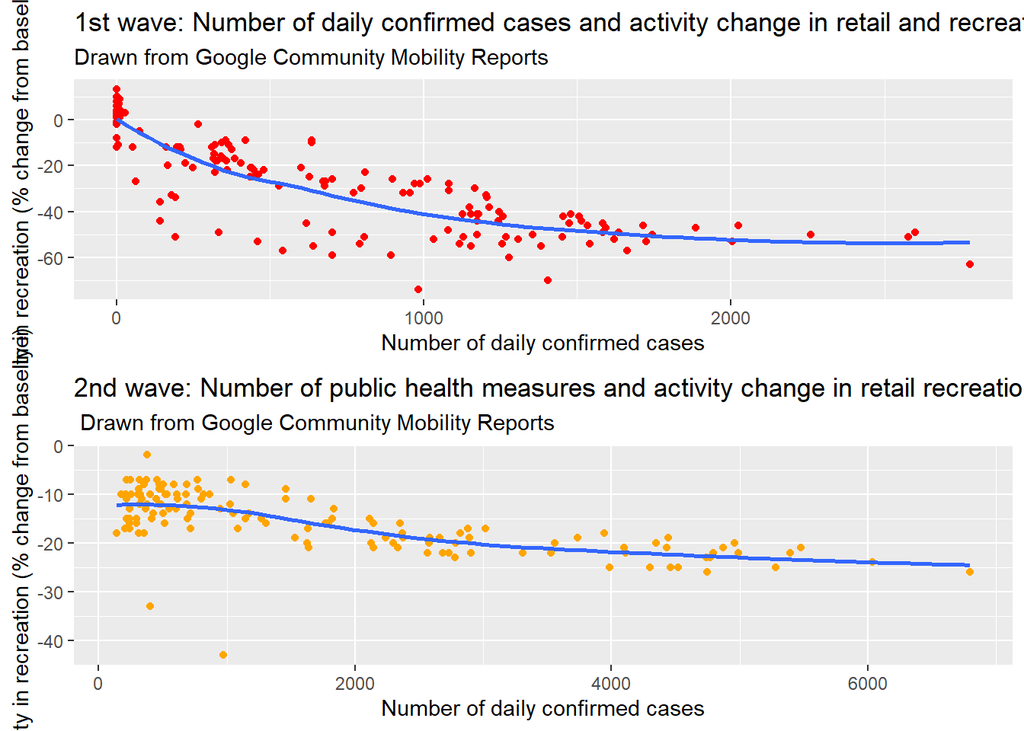

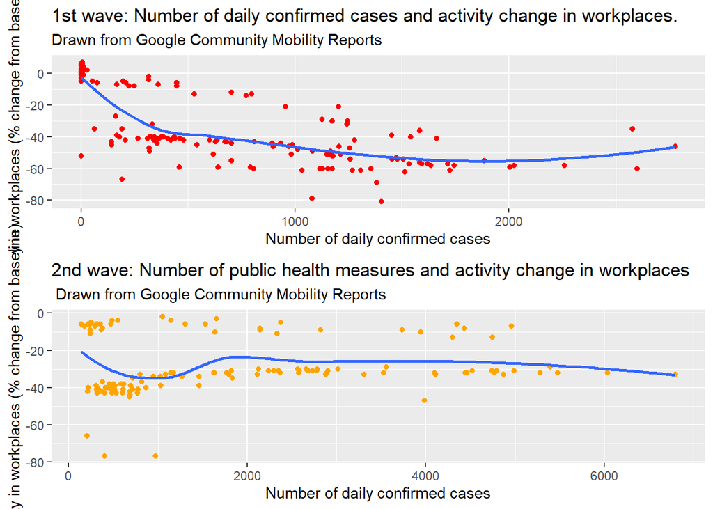

### Condiser other datasets.

##### now have a look into Government Response Index Tracker collected by Oxford University, the interpretation of the variables is [here](https://github.com/OxCGRT/covid-policy-tracker/blob/master/documentation/codebook.md)

The variables chosen shows below with definition and coding, each measured in ordinal scale.

[output not shown]

## Brazil.

#### 1.Activity change in retail and recreation places related to level of staying at home requirements.

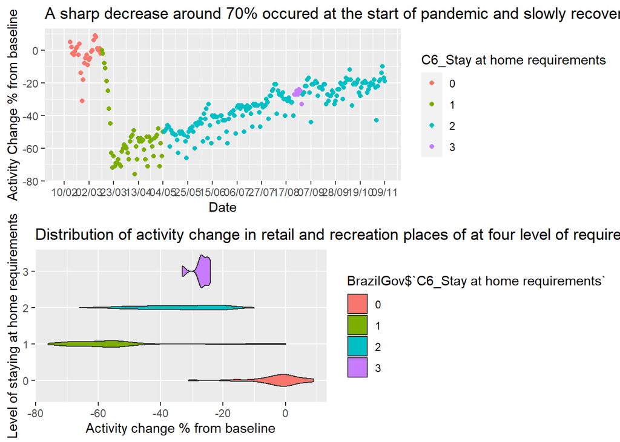

#### 2.Activity change in frequency that people visiting the residencial places, given level of requirements on staying at home.

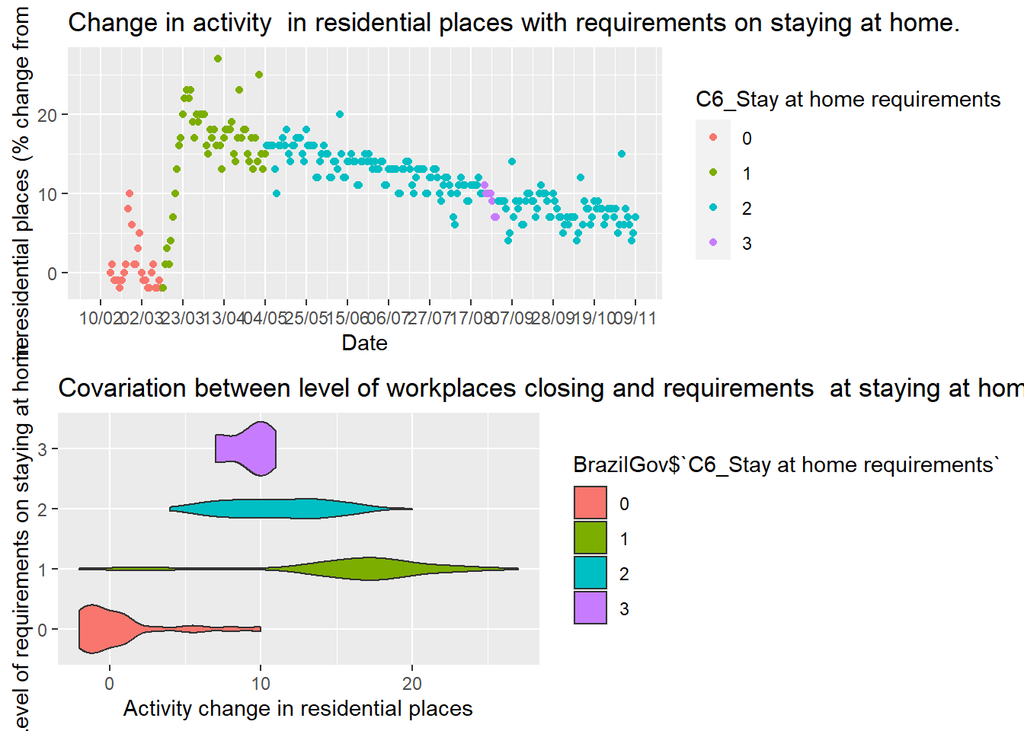

#### By the plot below, we observe that public reaction after different level of closing workplaces. The frequency of visiting workplaces sharply decreased after government required closing(or work from home) for all-but-essential workplaces (eg grocery stores, doctors). But in the mid-late people tend to visiting workplaces under level 3 closing policy.

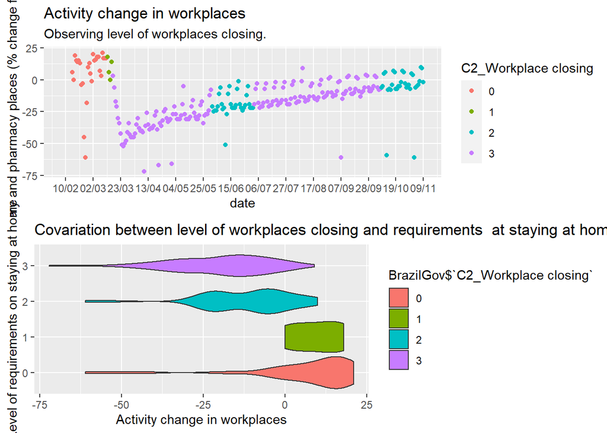

## Canada

#### 1. Staying at home requirements and retail and recreation places.

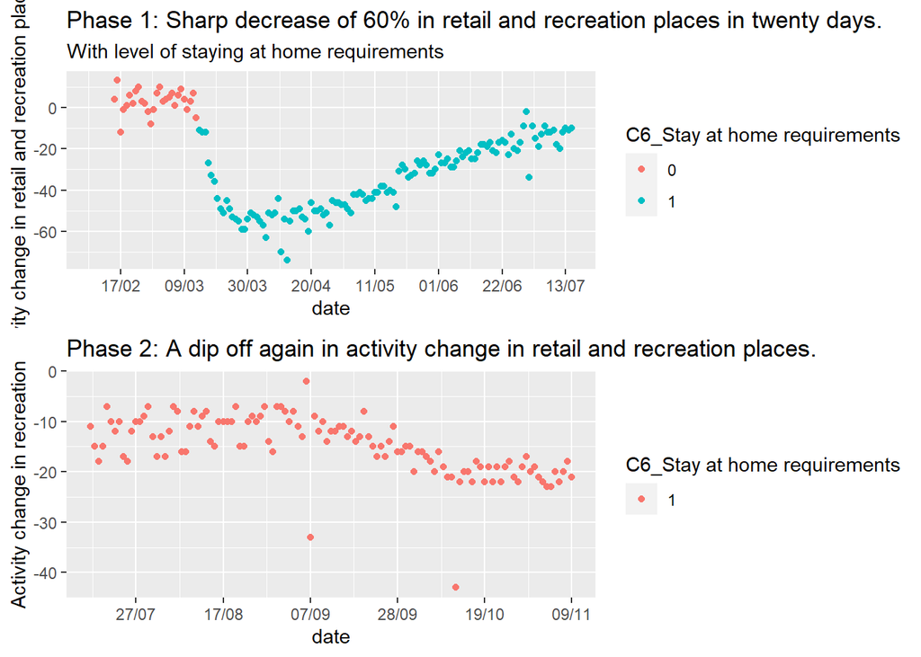

#### 2. Staying at home requirements & Residential activities.

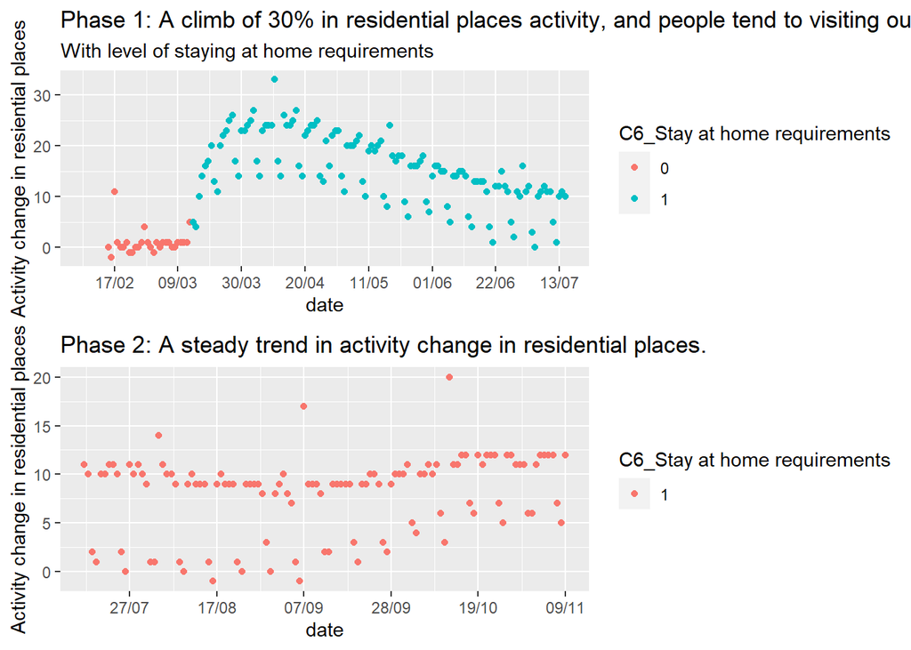

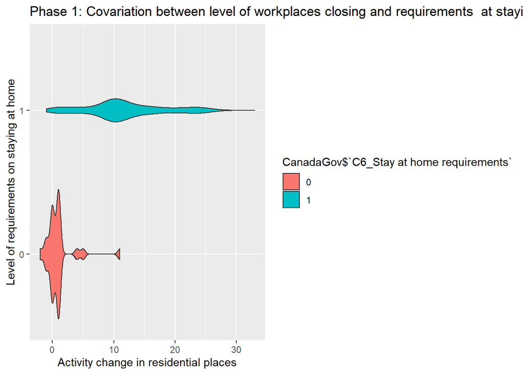

#### 3. workplaces closing & freuqency visiting workplaces

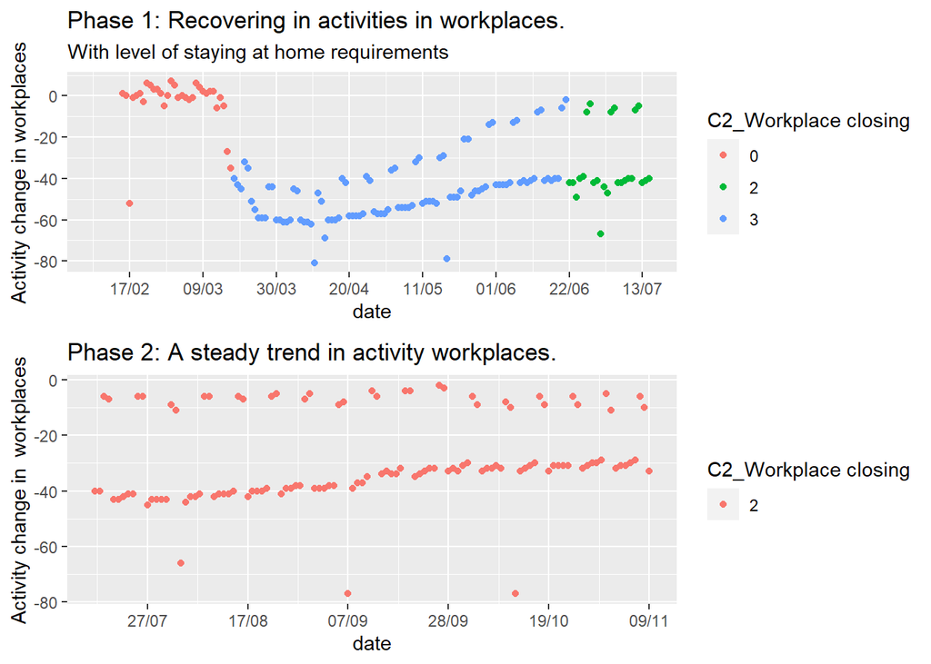

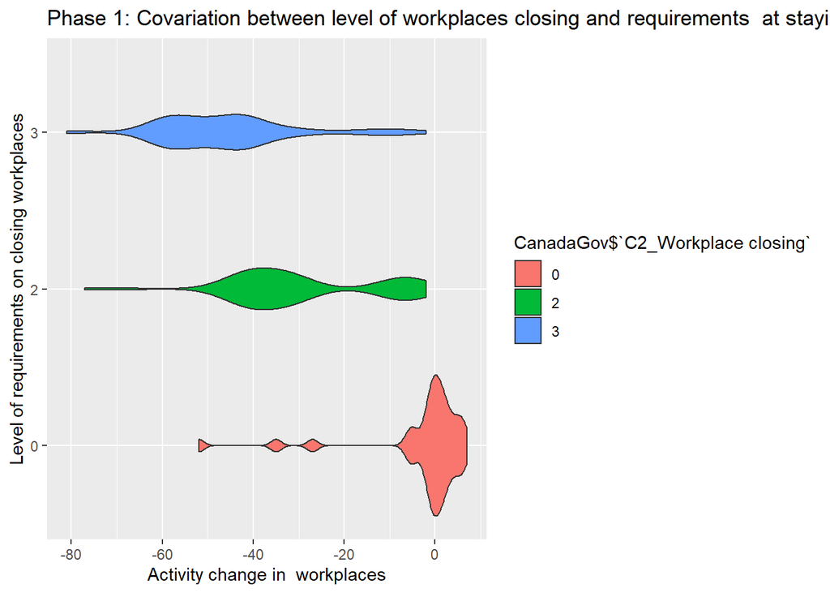